# Self-Driving Car Engineer Nanodegree

## Project: **Finding Lane Lines on the Road**

In this project, you will use the tools you learned about in the lesson to identify lane lines on the road. You can develop your pipeline on a series of individual images, and later apply the result to a video stream (really just a series of images). Check out the video clip "raw-lines-example.mp4" (also contained in this repository) to see what the output should look like after using the helper functions below.

Once you have a result that looks roughly like "raw-lines-example.mp4", you'll need to get creative and try to average and/or extrapolate the line segments you've detected to map out the full extent of the lane lines. You can see an example of the result you're going for in the video "P1_example.mp4". Ultimately, you would like to draw just one line for the left side of the lane, and one for the right.

In addition to implementing code, there is a brief writeup to complete. The writeup should be completed in a separate file, which can be either a markdown file or a pdf document. There is a [write up template](https://github.com/udacity/CarND-LaneLines-P1/blob/master/writeup_template.md) that can be used to guide the writing process. Completing both the code in the Ipython notebook and the writeup template will cover all of the [rubric points](https://review.udacity.com/#!/rubrics/322/view) for this project.

**The tools you have are color selection, region of interest selection, grayscaling, Gaussian smoothing, Canny Edge Detection and Hough Tranform line detection. You are also free to explore and try other techniques that were not presented in the lesson. Your goal is piece together a pipeline to detect the line segments in the image, then average/extrapolate them and draw them onto the image for display (as below). Once you have a working pipeline, try it out on the video stream below.**

[figure not shown]

Your output should look something like this (above) after detecting line segments using the helper functions below

[figure not shown]

Your goal is to connect/average/extrapolate line segments to get output like this

**Run the cell below to import some packages. If you get an `import error` for a package you've already installed, try changing your kernel (select the Kernel menu above --> Change Kernel). Still have problems? Try relaunching Jupyter Notebook from the terminal prompt. Also, consult the forums for more troubleshooting tips.**

## Import Packages

```python
#importing some useful packages
import matplotlib.pyplot as plt
import matplotlib.image as mpimg
import numpy as np
import cv2
import os
from scipy import stats
%matplotlib inline
```

## Helper Functions

Below are some helper functions to help get you started. They should look familiar from the lesson!

```python
import math

def grayscale(img):
    """Applies the Grayscale transform
    This will return an image with only one color channel
    but NOTE: to see the returned image as grayscale
    (assuming your grayscaled image is called 'gray')
    you should call plt.imshow(gray, cmap='gray')"""
    return cv2.cvtColor(img, cv2.COLOR_RGB2GRAY)
    # Or use BGR2GRAY if you read an image with cv2.imread()
    # return cv2.cvtColor(img, cv2.COLOR_BGR2GRAY)

def canny(img, low_threshold, high_threshold):
    """Applies the Canny transform"""
    return cv2.Canny(img, low_threshold, high_threshold)

def gaussian_blur(img, kernel_size):
    """Applies a Gaussian Noise kernel"""
    return cv2.GaussianBlur(img, (kernel_size, kernel_size), 0)

def region_of_interest(img, vertices):
    """
    Applies an image mask.

    Only keeps the region of the image defined by the polygon
    formed from `vertices`. The rest of the image is set to black.
    `vertices` should be a numpy array of integer points.
    """
    #defining a blank mask to start with
    mask = np.zeros_like(img)

    #defining a 3 channel or 1 channel color to fill the mask with depending on the input image
    if len(img.shape) > 2:
        channel_count = img.shape[2]  # i.e. 3 or 4 depending on your image
        ignore_mask_color = (255,) * channel_count
    else:
        ignore_mask_color = 255

    #filling pixels inside the polygon defined by "vertices" with the fill color
    cv2.fillPoly(mask, vertices, ignore_mask_color)

    #returning the image only where mask pixels are nonzero
    masked_image = cv2.bitwise_and(img, mask)
    return masked_image

def draw_lines(img, lines, yregion=0, color=[255, 0, 0], thickness=3):
    """

    This function draws `lines` with `color` and `thickness`.
    Lines are drawn on the image inplace (mutates the image).
    If you want to make the lines semi-transparent, think about combining
    this function with the weighted_img() function below
    """

    for line in lines:
        for x1,y1,x2,y2 in line:
            cv2.line(img, (x1, y1), (x2, y2), color, thickness)



def hough_lines(img, rho, theta, threshold, min_line_len, max_line_gap, draw_lines, yregion):
    """
    `img` should be the output of a Canny transform.

    Returns an image with hough lines drawn.
    """
    lines = cv2.HoughLinesP(img, rho, theta, threshold, np.array([]), minLineLength=min_line_len, maxLineGap=max_line_gap)
    line_img = np.zeros((img.shape[0], img.shape[1], 3), dtype=np.uint8)
    draw_lines(line_img, lines, yregion)
    return line_img

# Python 3 has support for cool math symbols.

def weighted_img(img, initial_img, α=0.8, β=1., γ=0.):
    """
    `img` is the output of the hough_lines(), An image with lines drawn on it.
    Should be a blank image (all black) with lines drawn on it.

    `initial_img` should be the image before any processing.

    The result image is computed as follows:

    initial_img * α + img * β + γ
    NOTE: initial_img and img must be the same shape!
    """
    return cv2.addWeighted(initial_img, α, img, β, γ)
```

# Separation and Extrapolation

A linear function is given with

$ y = a * x + b$

The coefficients a, b are computed with the function np.polyfit for each line. Dependend on the coefficient a(slope) the line is assigned to the left or right lane.

Since we know $y$ from the polygon vertices, rewrite the equation to obtain $ x = \frac{y -b}{a}$.

```python
def draw_lines_ext(img, lines, yregion, color=[255, 0, 0], thickness=3):
    """
    NOTE: this is the function you might want to use as a starting point once you want to
    average/extrapolate the line segments you detect to map out the full
    extent of the lane (going from the result shown in raw-lines-example.mp4
    to that shown in P1_example.mp4).

    Think about things like separating line segments by their
    slope ((y2-y1)/(x2-x1)) to decide which segments are part of the left
    line vs. the right line.  Then, you can average the position of each of
    the lines and extrapolate to the top and bottom of the lane.

    This function draws `lines` with `color` and `thickness`.
    Lines are drawn on the image inplace (mutates the image).
    If you want to make the lines semi-transparent, think about combining
    this function with the weighted_img() function below
    """

    left_lane = []
    right_lane = []
    left_p = np.empty([0, 2])
    right_p =  np.empty([0, 2])
    imshape = img.shape

    for line in lines:
        for x1,y1,x2,y2 in line:
            p = np.polyfit((x1, x2), (y1, y2) , 1)

            if p[0] > 0.35:
                right_p = np.vstack((right_p, p))
            elif p[0] < -0.35:
                left_p = np.vstack((left_p, p))

    left_p = left_p.mean(axis=0)
    right_p = right_p.mean(axis=0)

    ys = imshape[0]
    xs = int((ys - left_p[1]) / left_p[0])

    ye = yregion
    xe = int((ye - left_p[1]) / left_p[0])

    cv2.line(img, (xs, ys), (xe, ye), color, thickness)

    ys = imshape[0]
    xs = int((ys - right_p[1]) / right_p[0])

    ye = yregion
    xe = int((ye - right_p[1]) / right_p[0])

    cv2.line(img, (xs, ys), (xe, ye), color, thickness)
```

## Build a Lane Finding Pipeline

Try tuning the various parameters, especially the low and high Canny thresholds as well as the Hough lines parameters.

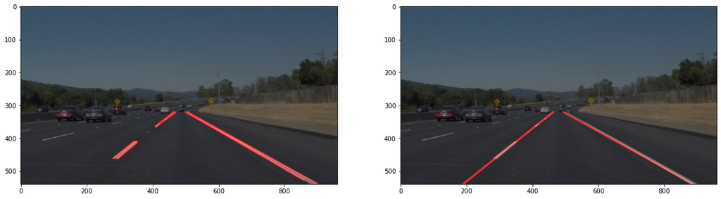

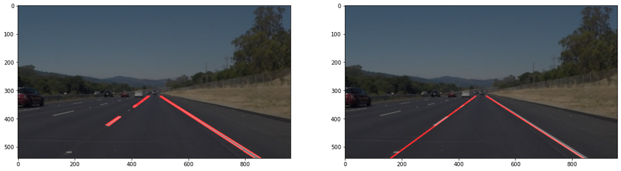

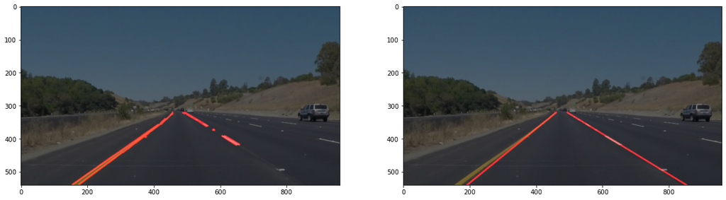

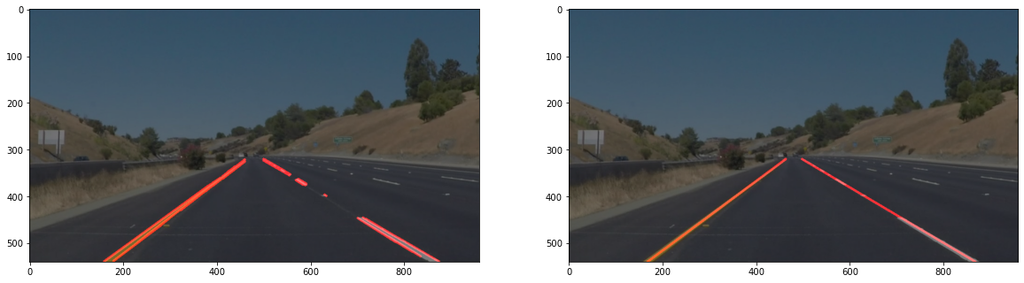

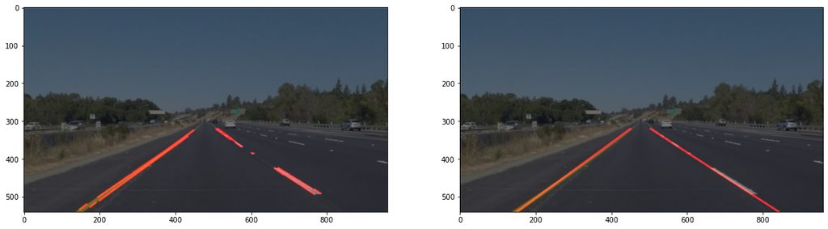

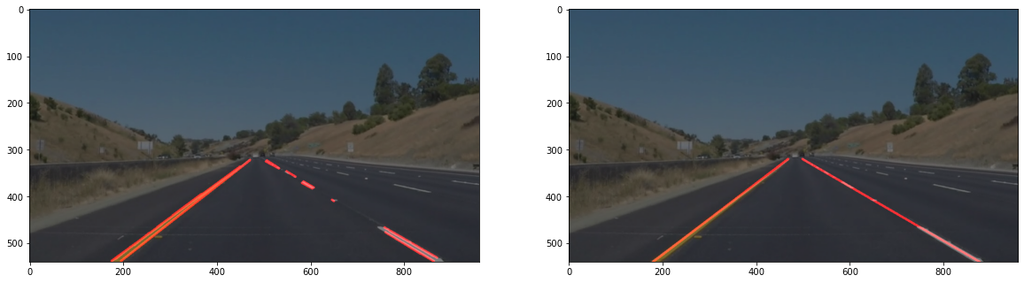

```python
imgdir = 'test_images'
outimgdir = 'test_images_output'
kernel = 3
low_threshold = 60
high_threshold = 150
rho = 7
theta = np.pi/180
threshold = 100
min_line_len = 2
max_line_gap = 10

for img_path in os.listdir(imgdir):
    img = mpimg.imread(os.path.join(imgdir, img_path))
    imshape = img.shape
#     plt.figure()
#     plt.imshow(img)

    yregion = 320
    vertices = np.array([[(120,imshape[0]),(430, yregion), (530, yregion), (imshape[1],550)]], dtype=np.int32)

    gray_img = grayscale(img)
    blur_img = gaussian_blur(gray_img, kernel)

    edges = canny(blur_img, low_threshold, high_threshold)
    edges = region_of_interest(edges, vertices)

#     plt.figure()
#     plt.imshow(edges, cmap='gray')

    line_img = hough_lines(edges, rho, theta, threshold, min_line_len, max_line_gap, draw_lines, yregion)
    final_img1 = weighted_img(line_img, img, α=0.5)
    cv2.imwrite(os.path.join(outimgdir, os.path.splitext(img_path)[0]+'_out.jpg'),
                cv2.cvtColor(final_img1, cv2.COLOR_RGB2BGR))

    line_img = hough_lines(edges, rho, theta, threshold, min_line_len, max_line_gap, draw_lines_ext, yregion)
    final_img2 = weighted_img(line_img, img, α=0.5)
    cv2.imwrite(os.path.join(outimgdir, os.path.splitext(img_path)[0]+r'_out_extended.jpg'),
                cv2.cvtColor(final_img2, cv2.COLOR_RGB2BGR))

#     plt.figure()
#     plt.imshow(line_img, cmap='gray')

    plt.figure(figsize=(20,20))
    plt.subplot(121)
    plt.imshow(final_img1)
    plt.subplot(122)
    plt.imshow(final_img2)
```

```python
# Import everything needed to edit/save/watch video clips
from moviepy.editor import VideoFileClip
from IPython.display import HTML
```

```python
from functools import partial
vertices = np.array([[(120,imshape[0]),(430, 320), (530, 320), (imshape[1],550)]], dtype=np.int32)

def process_image(image, draw_lines, vertices):

    kernel = 3
    low_threshold = 60
    high_threshold = 150
    rho = 7
    theta = np.pi/180
    threshold = 100
    min_line_len = 2
    max_line_gap = 10

    imshape = image.shape


    gray_img = grayscale(image)
    blur_img = gaussian_blur(gray_img, kernel)

    edges = canny(blur_img, low_threshold, high_threshold)
    edges = region_of_interest(edges, vertices)

    line_img = hough_lines(edges, rho, theta, threshold, min_line_len, max_line_gap, draw_lines, 320)

    final_img = weighted_img(line_img, image, α=0.5)

    return final_img

process_img = partial(process_image, draw_lines=draw_lines, vertices=vertices)
```

## Lane detection with simple draw line

```python
white_output = 'test_videos_output/solidWhiteRight.mp4'
## To speed up the testing process you may want to try your pipeline on a shorter subclip of the video
## To do so add .subclip(start_second,end_second) to the end of the line below
## Where start_second and end_second are integer values representing the start and end of the subclip
## You may also uncomment the following line for a subclip of the first 5 seconds
##clip1 = VideoFileClip("test_videos/solidWhiteRight.mp4").subclip(0,5)
clip1 = VideoFileClip("test_videos/solidWhiteRight.mp4")
white_clip = clip1.fl_image(process_img) #NOTE: this function expects color images!!
%time white_clip.write_videofile(white_output, audio=False)
```

```
Moviepy - Building video test_videos_output/solidWhiteRight.mp4.
Moviepy - Writing video test_videos_output/solidWhiteRight.mp4
```

```
Moviepy - Done !
Moviepy - video ready test_videos_output/solidWhiteRight.mp4
Wall time: 10.2 s
```

Play the video inline, or if you prefer find the video in your filesystem (should be in the same directory) and play it in your video player of choice.

```python
HTML("""
<video width="960" height="540" controls>
  <source src="{0}">
</video>
""".format(white_output))
```

[video not shown]

Now for the one with the solid yellow lane on the left. This one's more tricky!

```python
yellow_output = 'test_videos_output/solidYellowLeft.mp4'
## To speed up the testing process you may want to try your pipeline on a shorter subclip of the video
## To do so add .subclip(start_second,end_second) to the end of the line below
## Where start_second and end_second are integer values representing the start and end of the subclip
## You may also uncomment the following line for a subclip of the first 5 seconds
##clip2 = VideoFileClip('test_videos/solidYellowLeft.mp4').subclip(0,5)
clip2 = VideoFileClip('test_videos/solidYellowLeft.mp4')
yellow_clip = clip2.fl_image(process_img)
%time yellow_clip.write_videofile(yellow_output, audio=False)
```

```
Moviepy - Building video test_videos_output/solidYellowLeft.mp4.
Moviepy - Writing video test_videos_output/solidYellowLeft.mp4
```

```
Moviepy - Done !
Moviepy - video ready test_videos_output/solidYellowLeft.mp4
Wall time: 34.1 s
```

```python
HTML("""
<video width="960" height="540" controls>
  <source src="{0}">
</video>
""".format(yellow_output))
```

[video not shown]

## Lane detection with segmenation and interpolation

```python
process_img = partial(process_image, draw_lines=draw_lines_ext, vertices=vertices)
```

```python
white_output = 'test_videos_output/solidWhiteRight_full_lanes.mp4'
## To speed up the testing process you may want to try your pipeline on a shorter subclip of the video
## To do so add .subclip(start_second,end_second) to the end of the line below
## Where start_second and end_second are integer values representing the start and end of the subclip
## You may also uncomment the following line for a subclip of the first 5 seconds
##clip1 = VideoFileClip("test_videos/solidWhiteRight.mp4").subclip(0,5)
clip1 = VideoFileClip("test_videos/solidWhiteRight.mp4")
white_clip = clip1.fl_image(process_img) #NOTE: this function expects color images!!
%time white_clip.write_videofile(white_output, audio=False)
```

```
Moviepy - Building video test_videos_output/solidWhiteRight_full_lanes.mp4.
Moviepy - Writing video test_videos_output/solidWhiteRight_full_lanes.mp4
```

```
Moviepy - Done !
Moviepy - video ready test_videos_output/solidWhiteRight_full_lanes.mp4
Wall time: 21.5 s
```

```python
HTML("""
<video width="960" height="540" controls>
  <source src="{0}">
</video>
""".format(white_output))
```

[video not shown]

```python
yellow_output = 'test_videos_output/solidYellowLeft_full_lanes.mp4'
## To speed up the testing process you may want to try your pipeline on a shorter subclip of the video
## To do so add .subclip(start_second,end_second) to the end of the line below
## Where start_second and end_second are integer values representing the start and end of the subclip
## You may also uncomment the following line for a subclip of the first 5 seconds
##clip2 = VideoFileClip('test_videos/solidYellowLeft.mp4').subclip(0,5)
clip2 = VideoFileClip('test_videos/solidYellowLeft.mp4')
yellow_clip = clip2.fl_image(process_img)
%time yellow_clip.write_videofile(yellow_output, audio=False)
```

```
Moviepy - Building video test_videos_output/solidYellowLeft_full_lanes.mp4.
Moviepy - Writing video test_videos_output/solidYellowLeft_full_lanes.mp4
```

```
Moviepy - Done !
Moviepy - video ready test_videos_output/solidYellowLeft_full_lanes.mp4
Wall time: 40.5 s
```

```python
HTML("""
<video width="960" height="540" controls>
  <source src="{0}">
</video>
""".format(yellow_output))
```

[video not shown]

## Optional Challenge

Try your lane finding pipeline on the video below. Does it still work? Can you figure out a way to make it more robust? If you're up for the challenge, modify your pipeline so it works with this video and submit it along with the rest of your project!

```python
def process_image(image):

    kernel = 3

    low_threshold = 10
    high_threshold = 40
    rho = 7
    theta = np.pi/180
    threshold = 100
    min_line_len = 5
    max_line_gap = 2

    imshape = image.shape
    yregion = 475
    vertices = np.array([[(510,yregion),(790, yregion), (1175, 700), (150,700)]], dtype=np.int32)

    gray_img = grayscale(image)
    blur_img = gaussian_blur(gray_img, kernel)

    edges = canny(blur_img, 10, 30)
    edges = region_of_interest(edges, vertices)

    line_img = hough_lines(edges, rho, theta, threshold, min_line_len, max_line_gap, draw_lines_ext, yregion)

    final_img = weighted_img(line_img, image, α=0.5)

    return final_img
vertices = np.array([[(510,475),(790, 475), (1175, 700), (150,700)]], dtype=np.int32)
challenge_output = 'test_videos_output/challenge.mp4'
## To speed up the testing process you may want to try your pipeline on a shorter subclip of the video
## To do so add .subclip(start_second,end_second) to the end of the line below
## Where start_second and end_second are integer values representing the start and end of the subclip
## You may also uncomment the following line for a subclip of the first 5 seconds
# clip3 = VideoFileClip('test_videos/challenge.mp4').subclip(0,5)
clip3 = VideoFileClip('test_videos/challenge.mp4')
challenge_clip = clip3.fl_image(process_image)
%time challenge_clip.write_videofile(challenge_output, audio=False)
```

```
Moviepy - Building video test_videos_output/challenge.mp4.
Moviepy - Writing video test_videos_output/challenge.mp4
```

```
Moviepy - Done !
Moviepy - video ready test_videos_output/challenge.mp4
Wall time: 1min
```

```python
HTML("""
<video width="960" height="540" controls>
  <source src="{0}">
</video>
""".format(challenge_output))
```

[video not shown]